# Coursework MAP501 2022

```r
library("rio")
library("dplyr")
library("tidyr")
library("magrittr")
library("ggplot2")
library("pROC")
library("car")
library("nnet")
library("AmesHousing")
library("janitor")
library("here")
library("tidyverse")
library("corrr")
library("ggcorrplot")
library("effects")
library("rcompanion")
```

```r
Ames<-make_ames()
```

# 1. Data Preperatation

1. Import the soccer.csv dataset as “footballer_data”. (2 points)

```r
footballer_data <- clean_names(read_csv(here("data/soccer.csv")))
glimpse(footballer_data)
```

```
Rows: 570
Columns: 45
$ full_name                      <chr> "Aaron Cresswell", "Aaron Lennon", "Aar…
$ age                            <dbl> 32, 35, 31, 31, 22, 24, 25, 29, 27, 25,…
$ birthday                       <dbl> 629712000, 545554800, 653382000, 662198…
$ birthday_gmt                   <chr> "15/12/1989", "16/04/1987", "15/09/1990…
$ position                       <chr> "Defender", "Midfielder", "Midfielder",…
$ current_club                   <chr> "West Ham United", "Burnley", "Huddersf…
$ minutes_played_overall         <dbl> 1589, 1217, 2327, 1327, 69, 3135, 49, 3…
$ minutes_played_home            <dbl> 888, 487, 1190, 689, 14, 1605, 0, 1566,…
$ minutes_played_away            <dbl> 701, 730, 1137, 638, 55, 1530, 49, 1496…
$ nationality                    <chr> "England", "England", "Australia", "Wal…
$ appearances_overall            <dbl> 20, 16, 29, 28, 2, 35, 2, 35, 13, 0, 13…
$ appearances_home               <dbl> 11, 7, 15, 14, 1, 18, 0, 18, 8, 0, 6, 7…
$ appearances_away               <dbl> 9, 9, 14, 14, 1, 17, 2, 17, 5, 0, 7, 7,…
```

[output cut: 32 more lines]

2. Ensure all character variables are treated as factors and where variable names have a space, rename the variables without these. (3 points)

```r
footballer_data <- footballer_data %>%
  mutate_at(vars(full_name, nationality, current_club, position, birthday_gmt),
            list(factor))

#cleaned names when csv was read in, see 1.a
```

3. Remove the columns birthday and birthday_GMT. (2 points)

```r
footballer_data <- footballer_data %>%
  select(-birthday, -birthday_gmt)
```

d.Remove the cases with age<=15 and age>40. (2 points)

```r
footballer_data <- footballer_data %>%
  filter(age >= 16 & age <= 40)
```

# 2. Linear Regression

In this problem, you are going to investigate the response variable Total_Bsmt_SF in “Ames” dataset through linear regression.

1. By adjusting x axis range and number of bars, create a useful histogram of Total_Bsmt_SF (Total square feet of basement area) on the full dataset. Ensure that plot titles and axis labels are clear. (4 points)

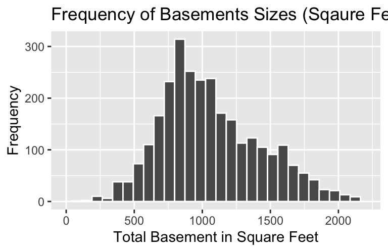

```
Rows: 2,930
Columns: 81
$ MS_SubClass        <fct> One_Story_1946_and_Newer_All_Styles, One_Story_1946…
$ MS_Zoning          <fct> Residential_Low_Density, Residential_High_Density, …
$ Lot_Frontage       <dbl> 141, 80, 81, 93, 74, 78, 41, 43, 39, 60, 75, 0, 63,…
$ Lot_Area           <int> 31770, 11622, 14267, 11160, 13830, 9978, 4920, 5005…
$ Street             <fct> Pave, Pave, Pave, Pave, Pave, Pave, Pave, Pave, Pav…
$ Alley              <fct> No_Alley_Access, No_Alley_Access, No_Alley_Access, …
$ Lot_Shape          <fct> Slightly_Irregular, Regular, Slightly_Irregular, Re…
$ Land_Contour       <fct> Lvl, Lvl, Lvl, Lvl, Lvl, Lvl, Lvl, HLS, Lvl, Lvl, L…
$ Utilities          <fct> AllPub, AllPub, AllPub, AllPub, AllPub, AllPub, All…
$ Lot_Config         <fct> Corner, Inside, Corner, Corner, Inside, Inside, Ins…
$ Land_Slope         <fct> Gtl, Gtl, Gtl, Gtl, Gtl, Gtl, Gtl, Gtl, Gtl, Gtl, G…
$ Neighborhood       <fct> North_Ames, North_Ames, North_Ames, North_Ames, Gil…
$ Condition_1        <fct> Norm, Feedr, Norm, Norm, Norm, Norm, Norm, Norm, No…
```

[output cut: 68 more lines]

```r
glimpse(Ames)

Ames %>%
  ggplot(aes(Total_Bsmt_SF))+
  geom_histogram(position = "identity", bin = 30, colour = "white")+
  labs(x="Total Basement in Square Feet",y="Frequency",
       title="Frequency of Basements Sizes (Sqaure Feet)") +
  xlim(0,2200)
```

2. Using “Ames” dataset to create a new dataset called “Ames2” in which you remove all cases corresponding to:

i.MS_Zoning categories of A_agr (agricultural), C_all (commercial) and I_all (industrial).

ii.BsmtFin_Type_1 category of “No_Basement”.

iii.Bldg_Type category of “OneFam” and drop the unused levels from the dataset “Ames2”. (4 points)

```r
Ames2 <- Ames %>%
  filter(BsmtFin_Type_1 != "No_Basement"& Bldg_Type != "OneFam" &
   !(MS_Zoning %in% c("A_agr","C_all","I_all")))

Ames2$BsmtFin_Type_1 <- droplevels(Ames2$BsmtFin_Type_1)
Ames2$Bldg_Type <- droplevels(Ames2$Bldg_Type)
Ames2$MS_Zoning <- droplevels(Ames2$MS_Zoning)

levels(Ames2$BsmtFin_Type_1)
levels(Ames2$Bldg_Type)
levels(Ames2$MS_Zoning)
```

```
[1] "ALQ" "BLQ" "GLQ" "LwQ" "Rec" "Unf"
[1] "TwoFmCon" "Duplex"   "Twnhs"    "TwnhsE"
[1] "Floating_Village_Residential" "Residential_High_Density"
[3] "Residential_Low_Density"      "Residential_Medium_Density"
```

3. Choose an appropriate plot to investigate the relationship between Bldg_Type and Total_Bsmt_SF in Ames2. (2 points)

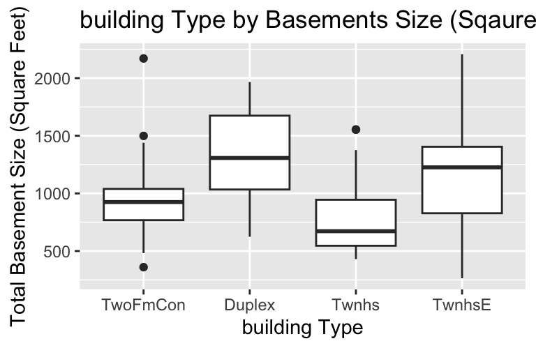

```r
Ames2 %>% ggplot(aes(Bldg_Type, Total_Bsmt_SF))+
  geom_boxplot() +
  labs(x="building Type",y="Total Basement Size (Square Feet)",
       title="building Type by Basements Size (Sqaure Feet)")
```

4. Choose an appropriate plot to investigate the relationship between Year_Built and Total_Bsmt_SF in Ames2. Color points according to the factor Bldg_Type. Ensure your plot has a clear title, axis labels and legend. What do you notice about how Basement size has changed over time? Were there any slowdowns in construction over this period? When? Can you think why? (4 points)

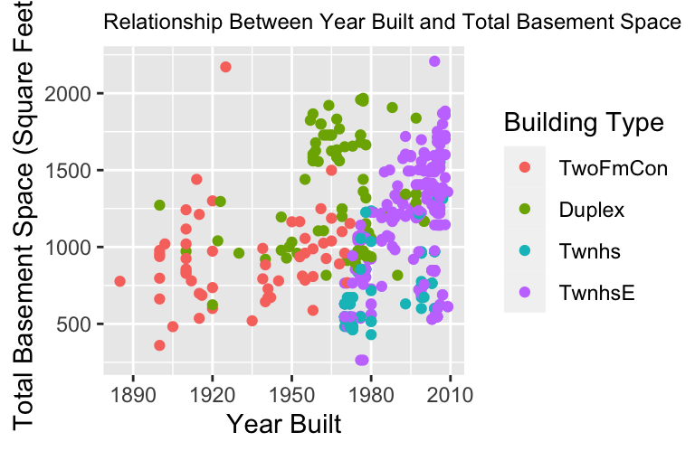

```r
Ames2 %>%
  ggplot(aes(x=Year_Built,y=Total_Bsmt_SF,
             colour = factor(Bldg_Type)))+
  geom_point()+
  labs(x = "Year Built", y = "Total Basement Space (Square Feet)") +
  ggtitle("Relationship Between Year Built and Total Basement Space") +
  labs(colour = "Building Type") +
  theme(plot.title = element_text(size = 9))
```

Basement sizes have increased more recently with duplex housing and town houses having the largest basement space in square feet. There was a slow down in construction between approximately 1920 and 1945. This could be due to world war 1 and world war 2 taking place between 1918 and 1945. Nations focuses were to defend the country rather than build new houses.

5. Why do we make these plots? Comment on your findings from these plots (1 sentence is fine). (2 points) We make these plots to visualise the data which helps to get a quick overall look at potential trends.
6. Now choose an appropriate plot to investigate the relationship between Bldg_Type and Year_Built in Ames2. Why should we consider this? What do you notice? (3 points)

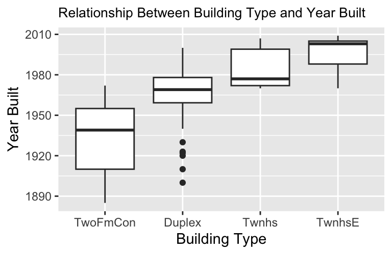

```r
Ames2 %>%
  ggplot(aes(x=Bldg_Type,y=Year_Built)) +
  geom_boxplot() +
  labs(x = "Building Type", y = "Year Built") +
  ggtitle("Relationship Between Building Type and Year Built") +
  theme(plot.title = element_text(size = 10))
```

Boxplots visually disply descriptive statistics about our data. This is useful to identify trends in the data. The median and skewness of data in these plots tell us that more Duplex’s, Twnhs’s and TwnhsE’s have been built recently compared to TwoFmCon’s.

7. Use the lm command to build a linear model, linmod1, of Total_Bsmt_SF as a function of the predictors Bldg_Type and Year_Built for the “Ames2” dataset. (2 points)

```r
linmod1<-lm(Total_Bsmt_SF~Year_Built + Bldg_Type ,data=Ames2)
summary(linmod1)
```

```
Call:
lm(formula = Total_Bsmt_SF ~ Year_Built + Bldg_Type, data = Ames2)

Residuals:
    Min      1Q  Median      3Q     Max
-738.53 -223.35    7.68  238.36 1306.23

Coefficients:
                  Estimate Std. Error t value Pr(>|t|)
(Intercept)     -1.293e+04  1.833e+03  -7.054 6.30e-12 ***
Year_Built       7.166e+00  9.478e-01   7.560 2.15e-13 ***
Bldg_TypeDuplex  1.870e+02  6.504e+01   2.875  0.00422 **
Bldg_TypeTwnhs  -5.314e+02  7.252e+01  -7.327 1.04e-12 ***
Bldg_TypeTwnhsE -2.349e+02  7.678e+01  -3.059  0.00235 **
---
Signif. codes:  0 '***' 0.001 '**' 0.01 '*' 0.05 '.' 0.1 ' ' 1

Residual standard error: 327.1 on 467 degrees of freedom
Multiple R-squared:  0.3339,    Adjusted R-squared:  0.3282
F-statistic: 58.54 on 4 and 467 DF,  p-value: < 2.2e-16
```

8. State and evaluate the assumptions of the model. (6 points)

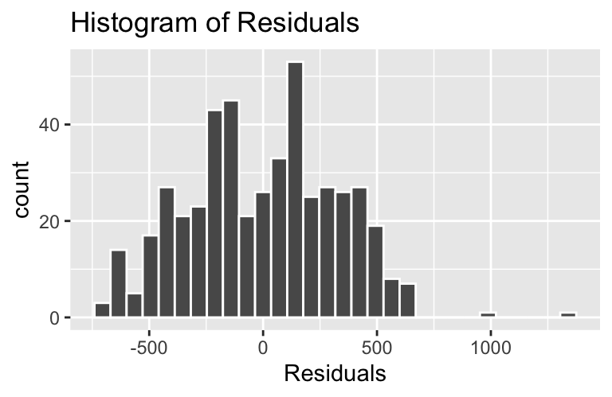

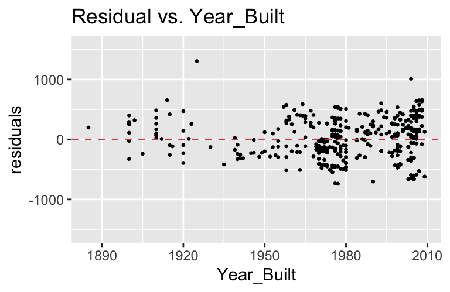

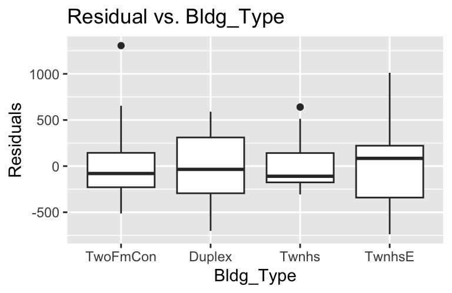

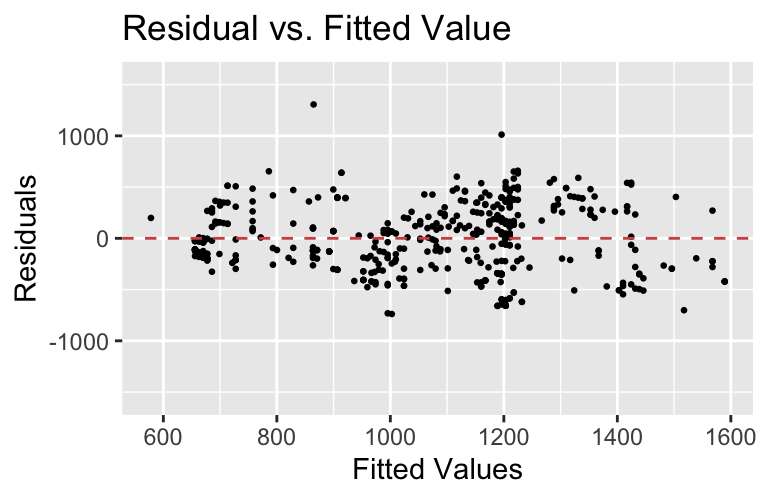

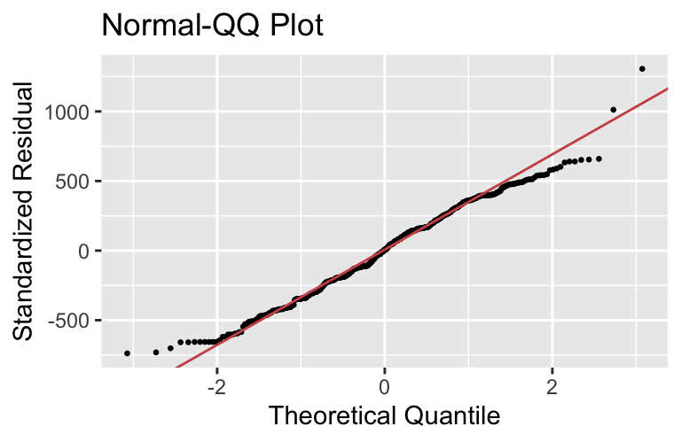

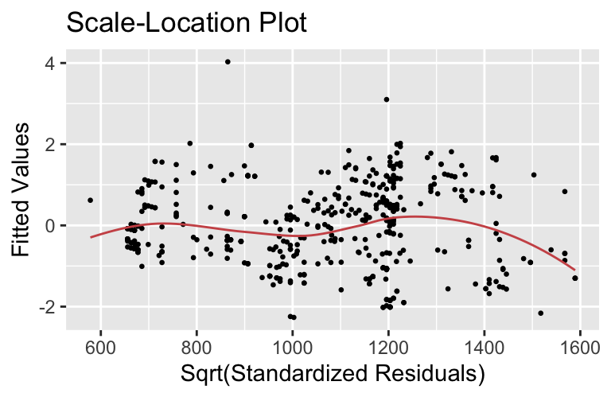

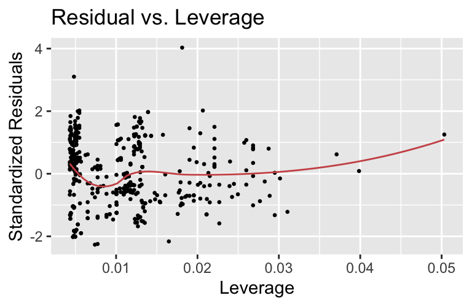

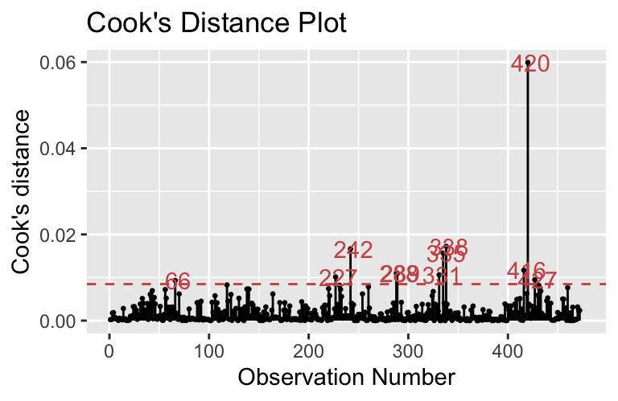

```r
library("lindia")
linmod1 %>%
  gg_diagnose(max.per.page = 1)
```

1. Use the lm command to build a second linear model, linmod2, for Total_Bsmt_SF as a function of Bldg_Type, Year_Built and Lot_Area. (2 points)

```r
linmod2<-lm(Total_Bsmt_SF~Year_Built + Bldg_Type + Lot_Area ,data=Ames2)
summary(linmod2)
```

```
Call:
lm(formula = Total_Bsmt_SF ~ Year_Built + Bldg_Type + Lot_Area,
    data = Ames2)

Residuals:
    Min      1Q  Median      3Q     Max
-810.32 -212.07   -5.72  233.88 1232.65

Coefficients:
                  Estimate Std. Error t value Pr(>|t|)
(Intercept)     -1.176e+04  1.828e+03  -6.435 3.08e-10 ***
Year_Built       6.509e+00  9.476e-01   6.868 2.09e-11 ***
Bldg_TypeDuplex  2.378e+02  6.529e+01   3.642 0.000301 ***
Bldg_TypeTwnhs  -4.120e+02  7.745e+01  -5.319 1.62e-07 ***
Bldg_TypeTwnhsE -1.265e+02  8.035e+01  -1.575 0.115942
Lot_Area         7.793e-03  1.960e-03   3.977 8.10e-05 ***
---
Signif. codes:  0 '***' 0.001 '**' 0.01 '*' 0.05 '.' 0.1 ' ' 1

Residual standard error: 322.1 on 466 degrees of freedom
Multiple R-squared:  0.3558,    Adjusted R-squared:  0.3489
F-statistic: 51.48 on 5 and 466 DF,  p-value: < 2.2e-16
```

10. Use anova and Adjusted R-squared to compare these two models, and decide which is a better model. (6 points)

```r
anova(linmod1,linmod2)

summary(linmod1)

summary(linmod2)
```

```
Analysis of Variance Table

Model 1: Total_Bsmt_SF ~ Year_Built + Bldg_Type
Model 2: Total_Bsmt_SF ~ Year_Built + Bldg_Type + Lot_Area
  Res.Df      RSS Df Sum of Sq      F    Pr(>F)
1    467 49980160
2    466 48339705  1   1640455 15.814 8.099e-05 ***
---
Signif. codes:  0 '***' 0.001 '**' 0.01 '*' 0.05 '.' 0.1 ' ' 1

Call:
lm(formula = Total_Bsmt_SF ~ Year_Built + Bldg_Type, data = Ames2)

Residuals:
    Min      1Q  Median      3Q     Max
-738.53 -223.35    7.68  238.36 1306.23

Coefficients:
                  Estimate Std. Error t value Pr(>|t|)
(Intercept)     -1.293e+04  1.833e+03  -7.054 6.30e-12 ***
Year_Built       7.166e+00  9.478e-01   7.560 2.15e-13 ***
Bldg_TypeDuplex  1.870e+02  6.504e+01   2.875  0.00422 **
Bldg_TypeTwnhs  -5.314e+02  7.252e+01  -7.327 1.04e-12 ***
Bldg_TypeTwnhsE -2.349e+02  7.678e+01  -3.059  0.00235 **
---
Signif. codes:  0 '***' 0.001 '**' 0.01 '*' 0.05 '.' 0.1 ' ' 1

Residual standard error: 327.1 on 467 degrees of freedom
Multiple R-squared:  0.3339,    Adjusted R-squared:  0.3282
F-statistic: 58.54 on 4 and 467 DF,  p-value: < 2.2e-16


Call:
lm(formula = Total_Bsmt_SF ~ Year_Built + Bldg_Type + Lot_Area,
    data = Ames2)

Residuals:
    Min      1Q  Median      3Q     Max
-810.32 -212.07   -5.72  233.88 1232.65

Coefficients:
                  Estimate Std. Error t value Pr(>|t|)
(Intercept)     -1.176e+04  1.828e+03  -6.435 3.08e-10 ***
Year_Built       6.509e+00  9.476e-01   6.868 2.09e-11 ***
Bldg_TypeDuplex  2.378e+02  6.529e+01   3.642 0.000301 ***
Bldg_TypeTwnhs  -4.120e+02  7.745e+01  -5.319 1.62e-07 ***
Bldg_TypeTwnhsE -1.265e+02  8.035e+01  -1.575 0.115942
Lot_Area         7.793e-03  1.960e-03   3.977 8.10e-05 ***
---
Signif. codes:  0 '***' 0.001 '**' 0.01 '*' 0.05 '.' 0.1 ' ' 1

Residual standard error: 322.1 on 466 degrees of freedom
Multiple R-squared:  0.3558,    Adjusted R-squared:  0.3489
F-statistic: 51.48 on 5 and 466 DF,  p-value: < 2.2e-16
```

The anova suggests that the second model which takes into account Lot_Area is an improvement over the first model. Model 2 was statistically significant with a p < 0.5. The first model has a Multiple R-squared value of 0.334. This means that 33% of variance in total basement size in square feet (Total_Bsmt_SF) is explained by year built (Year_Built) and dwelling type (Bldg_Type). So it is explanatory, however there are other uncontrolled factors which are influencing total basement size.

The second model has a Multiple R-squared value of 0.356. This means that 36% of variance in total basement size in square feet (Total_Bsmt_SF) is explained by year built (Year_Built), dwelling type (Bldg_Type) and lot size in square feet (Lot_Area). So it is more explanatory than the first model but only by 3% meaning that there are still uncontrolled factors which are influencing total basement size.

11. Construct a confidence interval and a prediction interval for the basement area of a Twnhs built in 1980, with a lot Area of 7300. Explain what these two intervals mean. (6 points)

```r
predict(linmod2,newdata=data.frame(Bldg_Type="Twnhs",
                                   Year_Built=1980,Lot_Area=7300),
                                   interval="confidence")
#confidence interval

predict(linmod2,newdata=data.frame(Bldg_Type="Twnhs",
                                   Year_Built=1980,Lot_Area=7300),
                                   interval="prediction")
#prediction interval
```

```
       fit      lwr      upr
1 768.7589 702.1423 835.3755
       fit      lwr      upr
1 768.7589 132.3605 1405.157
```

The confidence interval show us how ‘good’ our current estimate is. Whereas the prediction interval shows us a range in which a future response is likely to fall given specified predictors. The predicted value (fit) in our data is the same for both the confidence and predictions intervals, but the prediction interval is larger than the confidence interval.

12. Now build a linear mixed model, linmod3, for Total_Bsmt_SF as a function of Year_Built,MS_Zoning and Bldg_Type. Use Neighborhood as random effect. What is the critical number to pull out from this, and what does it tell us? (4 points)

```r
library("lme4")
linmod3 <- lmer(Total_Bsmt_SF~Year_Built+MS_Zoning+Bldg_Type+
                (1|Neighborhood),data=Ames2)
linmod3
```

```
Linear mixed model fit by REML ['lmerMod']
Formula:
Total_Bsmt_SF ~ Year_Built + MS_Zoning + Bldg_Type + (1 | Neighborhood)
   Data: Ames2
REML criterion at convergence: 6566.758
Random effects:
 Groups       Name        Std.Dev.
 Neighborhood (Intercept) 187.4
 Residual                 261.8
Number of obs: 472, groups:  Neighborhood, 27
Fixed Effects:
                        (Intercept)                           Year_Built
                          -4890.652                                2.876
  MS_ZoningResidential_High_Density     MS_ZoningResidential_Low_Density
                            148.504                              288.369
MS_ZoningResidential_Medium_Density                      Bldg_TypeDuplex
                            109.234                              264.530
                     Bldg_TypeTwnhs                      Bldg_TypeTwnhsE
                            -63.140                              105.171
```

13. Construct 95% confidence intervals around each parameter estimate for linmod3. What does this tell us about the significant of the random effect? (3 points)

```r
confint(linmod3)
```

```
                                           2.5 %     97.5 %
.sig01                                114.916972  253.19244
.sigma                                244.221572  278.77404
(Intercept)                         -9699.022207 -595.99553
Year_Built                              0.691417    5.33084
MS_ZoningResidential_High_Density    -254.190137  549.38121
MS_ZoningResidential_Low_Density      -91.829020  665.77648
MS_ZoningResidential_Medium_Density  -266.136920  487.72182
Bldg_TypeDuplex                       145.073466  377.00462
Bldg_TypeTwnhs                       -249.148897  102.22240
Bldg_TypeTwnhsE                       -68.266514  263.18536
```

14. Write out the full mathematical expression for the model in linmod2 and for the model in linmod3. Round to the nearest integer in all coefficients with modulus > 10 and to three decimal places for coefficients with modulus < 10. (4 points)

```r
library("knitr")
summary(linmod2)
```

```
Call:
lm(formula = Total_Bsmt_SF ~ Year_Built + Bldg_Type + Lot_Area,
    data = Ames2)

Residuals:
    Min      1Q  Median      3Q     Max
-810.32 -212.07   -5.72  233.88 1232.65

Coefficients:
                  Estimate Std. Error t value Pr(>|t|)
(Intercept)     -1.176e+04  1.828e+03  -6.435 3.08e-10 ***
Year_Built       6.509e+00  9.476e-01   6.868 2.09e-11 ***
Bldg_TypeDuplex  2.378e+02  6.529e+01   3.642 0.000301 ***
Bldg_TypeTwnhs  -4.120e+02  7.745e+01  -5.319 1.62e-07 ***
Bldg_TypeTwnhsE -1.265e+02  8.035e+01  -1.575 0.115942
Lot_Area         7.793e-03  1.960e-03   3.977 8.10e-05 ***
---
Signif. codes:  0 '***' 0.001 '**' 0.01 '*' 0.05 '.' 0.1 ' ' 1

Residual standard error: 322.1 on 466 degrees of freedom
Multiple R-squared:  0.3558,    Adjusted R-squared:  0.3489
F-statistic: 51.48 on 5 and 466 DF,  p-value: < 2.2e-16
```

Linmod2 equation

$$\begin{align}
\mbox{E(Total Basement Space)} \sim &-11760 + 6.509\times {\rm
Year\ Built} \\
&+238\times{\rm BldgType\ Duplex} +
-412\times {\rm BldgType\ Twnhs} \\
&-127\times {\rm BldgType\ TwnhsE}\\
&0.008\times {\rm Lot\ Area}, 322.
\end{align}$$

```r
summary(linmod3)
```

```
Linear mixed model fit by REML ['lmerMod']
Formula:
Total_Bsmt_SF ~ Year_Built + MS_Zoning + Bldg_Type + (1 | Neighborhood)
   Data: Ames2

REML criterion at convergence: 6566.8

Scaled residuals:
    Min      1Q  Median      3Q     Max
-2.1502 -0.5804 -0.0394  0.6330  4.4359

Random effects:
 Groups       Name        Variance Std.Dev.
 Neighborhood (Intercept) 35128    187.4
 Residual                 68517    261.8
Number of obs: 472, groups:  Neighborhood, 27

Fixed effects:
                                     Estimate Std. Error t value
(Intercept)                         -4890.652   2262.148  -2.162
Year_Built                              2.876      1.151   2.499
MS_ZoningResidential_High_Density     148.504    211.630   0.702
MS_ZoningResidential_Low_Density      288.369    198.824   1.450
MS_ZoningResidential_Medium_Density   109.234    197.814   0.552
Bldg_TypeDuplex                       264.530     59.046   4.480
Bldg_TypeTwnhs                        -63.140     87.020  -0.726
Bldg_TypeTwnhsE                       105.171     83.438   1.260

Correlation of Fixed Effects:
            (Intr) Yr_Blt MS_ZR_H MS_ZR_L MS_ZR_M Bld_TD Bld_TT
Year_Built  -0.996
MS_ZnnR_H_D -0.158  0.081
MS_ZnnR_L_D -0.169  0.085  0.912
MS_ZnnR_M_D -0.142  0.061  0.901   0.963
Bldg_TypDpl  0.378 -0.395  0.014  -0.017  -0.001
Bldg_TypTwn  0.546 -0.570  0.004   0.059  -0.006   0.617
Bldg_TypTwE  0.602 -0.626 -0.005   0.052  -0.010   0.662  0.911
```

Linmod3 equation

$$\begin{align}
\mbox{E(Total Basement Space)} \sim{} &-4891 + 3\times {\rm Year\
Built}\ + \\
&149\times{\rm MS\ Zoning\ Residential\ High\ Density} \ + \\
&288\times {\rm Residential\ Low\ Density}\ +\\
&109\times {\rm Residential\ Medium\ Density} \ +\\
&265\times {\rm Bldg\ Type\ Duplex }\ +\\
&-63\times {\rm Bldg\ Type\ Twnhs }\ +\\
&105\times {\rm Bldg\ Type\ TwnhsE + U.}\\
\\
U \sim{} N(0,\ 187)\\
\end{align}$$

# 3. Logistic Regression

1. Do the following:
2. Create a new dataset called “Ames3” that contains all data in “Ames” dataset plus a new variable “excellent_heating” that indicates if the heating quality and condition “Heating_QC” is excellent or not. (2 points)

```r
Ames3 <- Ames %>%
  mutate(excellent_heating = Heating_QC == "Excellent")
```

2. In “Ames3” dataset, remove all cases “3” and “4” corresponding to the Fireplaces variable. Remove all cases where Lot_Frontage is greater than 130 or smaller than 20. Drop the unused levels from .(2 points)
3. Save “Fireplaces” as factor in “Ames3” dataset (1 point)

```r
Ames3 <- Ames3 %>%
  mutate_at(vars(Fireplaces),
            list(factor)) %>%
  filter(Fireplaces != 3 & 4) %>%
  filter(Lot_Frontage <= 130 & Lot_Frontage >= 20)

Ames3$Fireplaces <- droplevels(Ames3$Fireplaces)
```

4. Construct a logistic regression model glmod for excellent_heating as a function of Lot_Frontage and Fireplaces for the dataset “Ames3”. (2 points)

```r
glmod <- glm(as.factor(excellent_heating)~Lot_Frontage + Fireplaces,
             family="binomial",data=Ames3)
summary(glmod)
```

```
Call:
glm(formula = as.factor(excellent_heating) ~ Lot_Frontage + Fireplaces,
    family = "binomial", data = Ames3)

Deviance Residuals:
    Min       1Q   Median       3Q      Max
-1.5932  -1.0761   0.8695   1.0442   1.4503

Coefficients:
               Estimate Std. Error z value Pr(>|z|)
(Intercept)   -0.769387   0.147977  -5.199    2e-07 ***
Lot_Frontage   0.007018   0.002137   3.285  0.00102 **
Fireplaces1    0.796183   0.088528   8.994  < 2e-16 ***
Fireplaces2    0.494887   0.176308   2.807  0.00500 **
Fireplaces4  -12.498519 324.743710  -0.038  0.96930
---
Signif. codes:  0 '***' 0.001 '**' 0.01 '*' 0.05 '.' 0.1 ' ' 1

(Dispersion parameter for binomial family taken to be 1)

    Null deviance: 3325.6  on 2400  degrees of freedom
Residual deviance: 3213.3  on 2396  degrees of freedom
AIC: 3223.3

Number of Fisher Scoring iterations: 11
```

2. Construct confidence bands for the variable excellent_heating as a function of Lot_Frontage for each number of Fireplaces (hint: create a new data frame for each number of Fireplaces). Colour these with different transparent colours for each number of Fireplaces and plot them together on the same axes. Put the actual data on the plot, coloured to match the bands, and jittered in position to make it possible to see all points. Ensure you have an informative main plot title, axes labels and a legend. (7 points)

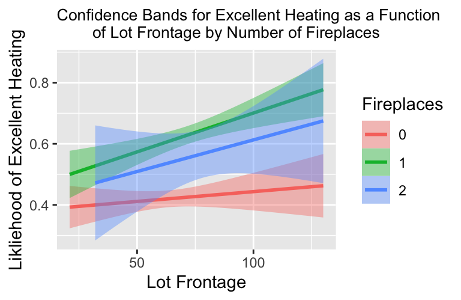

```r
ggplot(Ames3, aes(x=Lot_Frontage, y=as.numeric
                  (as.factor(excellent_heating))-1)) +
  geom_smooth(method=glm, aes(colour=Fireplaces, fill=Fireplaces)) +
  #adding - geom_point(position = "jitter") + - made the graph look messy
  #so ommitted.
  labs(x="Lot Frontage", y="Likliehood of Excellent Heating") +
  ggtitle("Confidence Bands for Excellent Heating as a Function
        of Lot Frontage by Number of Fireplaces") +
  theme(plot.title = element_text(size = 10))
```

3. Split the data using set.seed(120) and rebuild the model on 80% of the data. Cross validate on the remaining 20%. Plot the ROCs for both data and comment on your findings. (6 points)

```r
library("caret")

#split the data and rebuilt model on 80% of data
set.seed(120)
training.samples <- c(Ames3$excellent_heating) %>%
  createDataPartition(p = 0.8, list = FALSE)
train.data <- Ames3[training.samples, ]
test.data <- Ames3[-training.samples, ]
```

```r
#then created the a new model on the training data
train.model <- glm(as.factor(excellent_heating)~Lot_Frontage + Fireplaces,
             family="binomial",data=train.data)
```

```r
predtrain <- predict(train.model,type="response")
predtest <- predict(train.model,newdata=test.data,type="response")
```

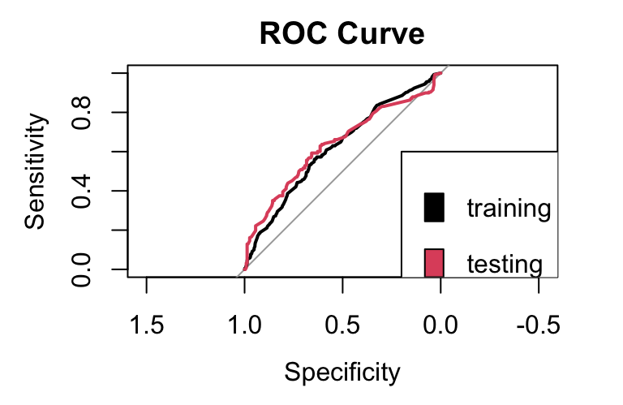

```
Call:
roc.default(response = test.data$excellent_heating, predictor = predtest,     auc = TRUE, plot = TRUE, add = TRUE, col = 2)

Data: predtest in 231 controls (test.data$excellent_heating FALSE) < 248 cases (test.data$excellent_heating TRUE).
Area under the curve: 0.6352
```

```r
roctrain <- roc(response=train.data$excellent_heating,predictor=predtrain,
                plot=TRUE,
                main="ROC Curve",auc=TRUE)

roc(response=test.data$excellent_heating,predictor=predtest,
     plot=TRUE,auc=TRUE,add=TRUE,col=2)

legend(0.2,0.6,legend=c("training","testing"),fill=1:2)
```

The graph shows that the two lines are fairly similar, meaning that the testing data is not overfitted to the training data.

# 4. Multinomial Regression

1. For the dataset “Ames”, create a model multregmod to predict BsmtFin_Type_1 (Rating of basement finished area) from Total_Bsmt_SF and Year_Remod_Add Remodel date (same as construction date if no remodeling or additions). (3 points)

```r
multregmod <- multinom(BsmtFin_Type_1~Total_Bsmt_SF+Year_Remod_Add,data=Ames)
multregmod

predict(multregmod,type="probs")[1,]
```

```
Call:
multinom(formula = BsmtFin_Type_1 ~ Total_Bsmt_SF + Year_Remod_Add,
    data = Ames)

Coefficients:
            (Intercept) Total_Bsmt_SF Year_Remod_Add
BLQ           34.465254  6.282504e-05   -0.017706708
GLQ         -105.324418  1.030040e-03    0.052676145
LwQ           39.566891  1.243787e-05   -0.020550529
No_Basement    4.876103 -1.729079e-01    0.004007987
Rec           56.710979  1.596801e-06   -0.028929851
Unf          -29.377212 -6.987213e-04    0.015514051

Residual Deviance: 8288.95
AIC: 8324.95
         ALQ          BLQ          GLQ          LwQ  No_Basement          Rec
1.981294e-01 1.668137e-01 7.535347e-02 9.851482e-02 5.319856e-77 2.001598e-01
         Unf
2.610287e-01
```

2. Write out the formulas for this model in terms of P(No_Basement), P(Unf) P(Rec),P(BLQ), P(GLQ), P(LwQ), You may round coefficients to 3 dp. (4 points)

$$\begin{align}
\mbox{logit(P(BLQ))} \ =
&\ 34.465 + 0.00006282504\times {\rm Total\ Bsmt\ SF}\ +\\
&-0.018\times {\rm Year\ Remod\ Add. }\\
\\
\mbox{logit(P(GLQ))} \ =
&\ -105.324 + 0.001030040\times {\rm Total\ Bsmt\ SF}\ +\\
&0.053\times {\rm Year\ Remod\ Add. }\\
\\
\mbox{logit(P(LwQ))} \ =
&\ 39.567 + 0.00001243787\times {\rm Total\ Bsmt\ SF}\ +\\
&-0.021\times {\rm Year\ Remod\ Add. }\\
\\
\mbox{logit(P(No Basement))} \ =
&\ 4.876 + -0.1729079\times {\rm Total\ Bsmt\ SF}\ +\\
&0.004\times {\rm Year\ Remod\ Add. }\\
\\
\mbox{logit(P(Rec))} \ =
&\ 56.711 + 0.000001596801\times {\rm Total\ Bsmt\ SF}\ +\\
&-0.029\times {\rm Year\ Remod\ Add. }\\
\\
\mbox{logit(P(Unf))} \ =
&\ -29.377 + -0.0006987213\times {\rm Total\ Bsmt\ SF}\ +\\
&0.016\times {\rm Year\ Remod\ Add. }\\
\\
P(ALQ)\ = &\ 1- P(BLQ)\ - P(GLQ)\ - \\
&P(LwQ)\ - P(No\ Basement)\ - \\
&P(Rec)\ -P(Unf).
\end{align}$$

3. Evaluate the performance of this model using a confusion matrix and by calculating the sum of sensitivities for the model. Comment on your findings. (4 points)

```r
multitable <- table(Ames$BsmtFin_Type_1,predict(multregmod,type="class"))
names(dimnames(multitable))<- list("Actual","Predicted")
multitable
```

```
             Predicted
Actual        ALQ BLQ GLQ LwQ No_Basement Rec Unf
  ALQ           1   0 117   0           0  18 293
  BLQ           0   0  50   0           0  30 189
  GLQ           1   0 579   0           0   2 277
  LwQ           1   0  38   0           0  30  85
  No_Basement   0   0   0   0          80   0   0
  Rec           3   0  31   0           0  46 208
  Unf           6   0 291   0           0  76 478
```